# IE 360 Homework 4 & 5

Since there are not enough data points, decomposition cannot made in different levels. Although we cannot decompose, weekly and monthly plots can be seen below.

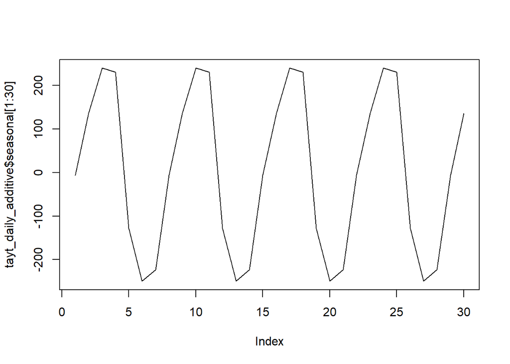

```r
plot(tayt_daily_additive$seasonal[1:30], type='l')
```

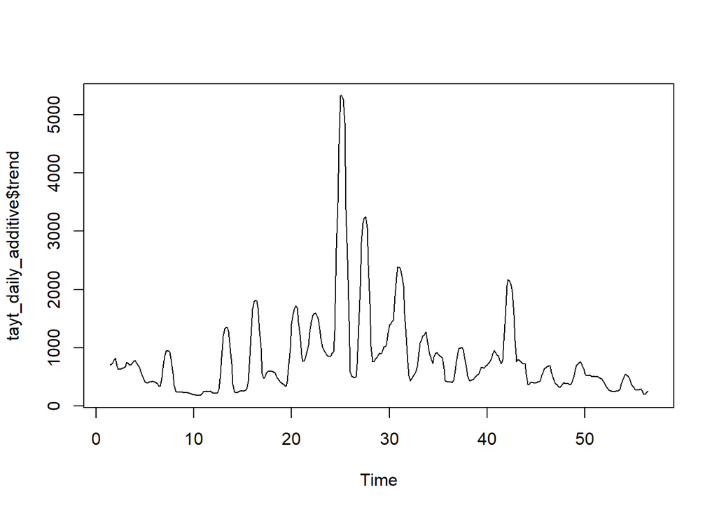

```r
plot(tayt_daily_additive$trend, type='l')
```

Weekly

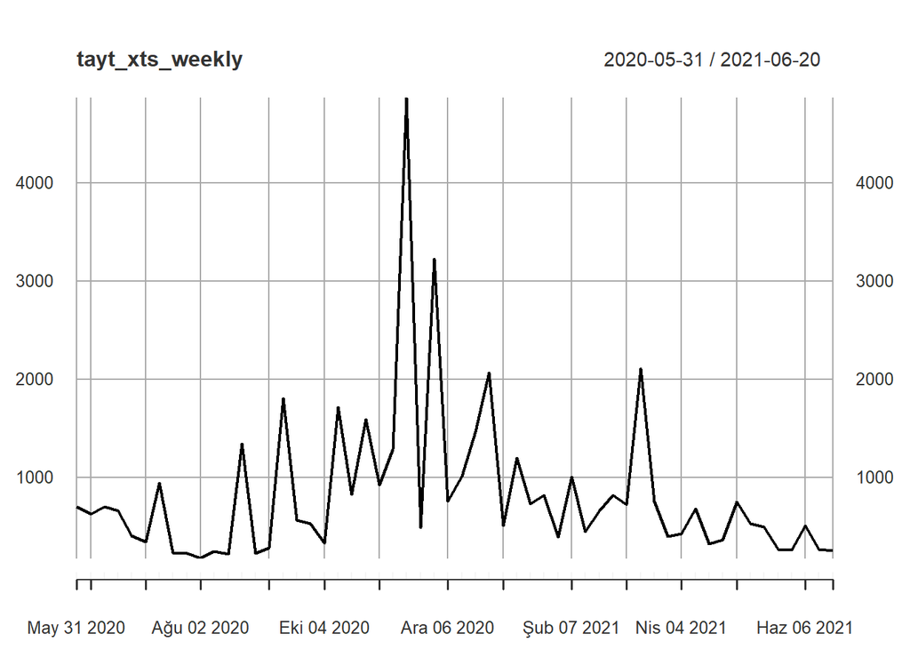

```r
tayt_xts<-xts(tayt_daily_tr$sold_count, order.by=as.Date(tayt_daily_tr$event_date,"%d.%m.%Y"))
weekly<-endpoints(tayt_xts,on="weeks")
tayt_xts_weekly<-period.apply(tayt_xts,INDEX=weekly,FUN=mean)
plot(tayt_xts_weekly)
```

Monthly

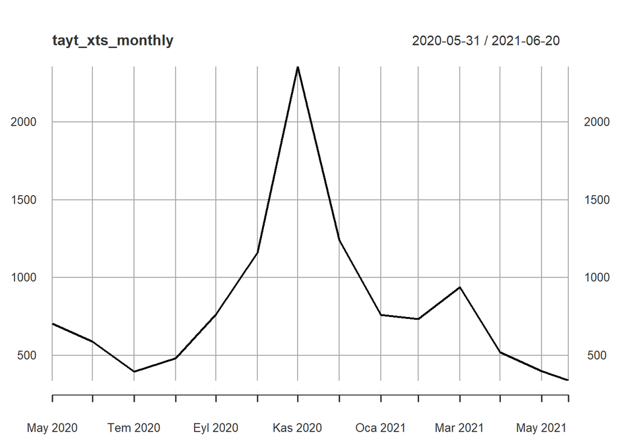

```r
tayt_xts<-xts(tayt_daily_tr$sold_count, order.by=as.Date(tayt_daily_tr$event_date,"%d.%m.%Y"))
monthly<-endpoints(tayt_xts,on="months")
tayt_xts_monthly<-period.apply(tayt_xts,INDEX=monthly,FUN=mean)
plot(tayt_xts_monthly)
```

It can be seen that sales volumes of tayt increased at November influenced by the discount days, which are determined in our project to yield better forecast result.

## ARIMA Model

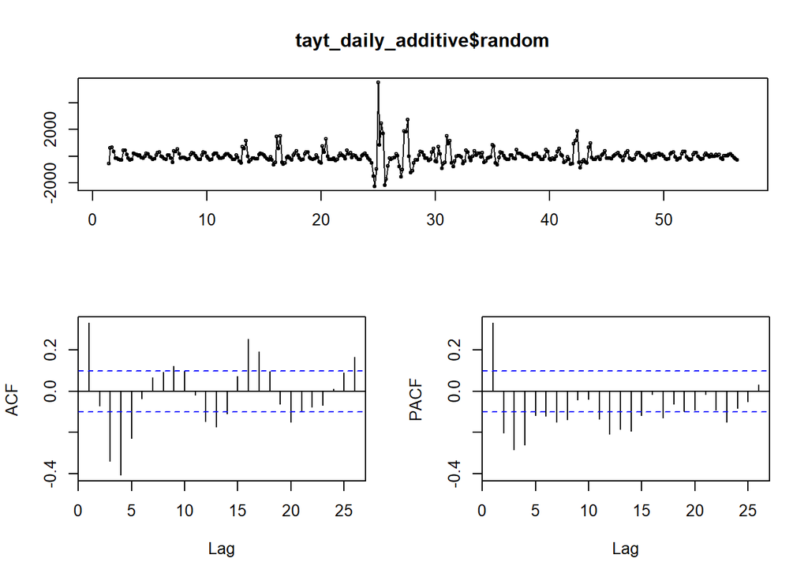

```r
tsdisplay(tayt_daily_additive$random, na.action = na.omit)
```

According to ACF plot, there is significant negative correlation at lag 4. Hence, moving average parameter should be 4. Also, it can be seen from PACF plot that correlation significantly decreased after lag 1 which means that AR parameter should be 1.

```r
tayt_model<-arima(tayt_daily_additive$random, order = c(1,0,4))
AIC(tayt_model)
```

```
## [1] 5838.382
```

```r
tayt_model2<-arima(tayt_daily_additive$random, order = c(1,0,3))
AIC(tayt_model2)
```

```
## [1] 5852.143
```

```r
tayt_model3<-arima(tayt_daily_additive$random, order = c(1,0,2))
AIC(tayt_model3)
```

```
## [1] 5953.414
```

When adjacent parameters also checked, still model 1 which has (1,0,4) parameters is better in terms of AIC values, therefore it is chosen.

Fitting the model

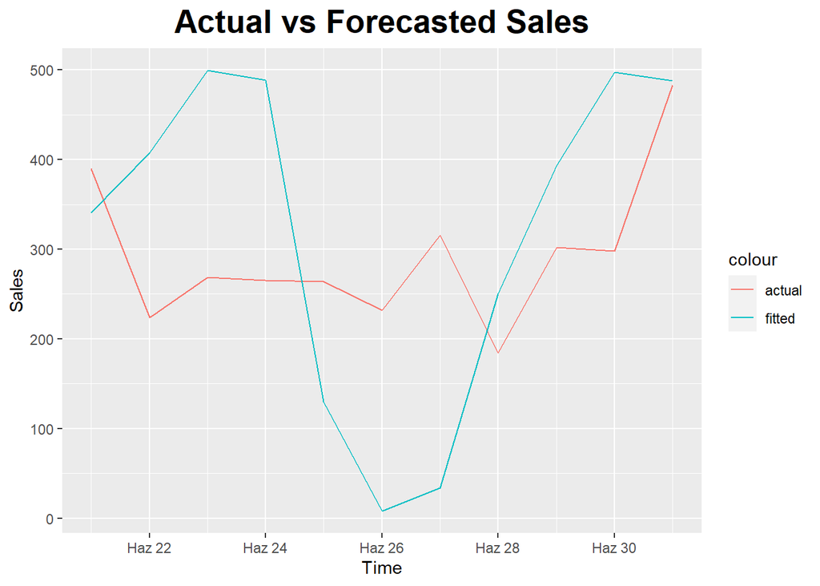

```r
model_forecast_error <- predict(tayt_model, n.ahead = 11)$pred
last_trend_value <-tail(tayt_daily_additive$trend[!is.na(tayt_daily_additive$trend)],1)
seasonality=tayt_daily_additive$seasonal[295:305]
tayt_arima_forecast=model_forecast_error+seasonality+last_trend_value

tayt_daily_te$forecast<-paste(tayt_arima_forecast)
tayt_daily_te$forecast<-as.numeric(tayt_daily_te$forecast)


ggplot(tayt_daily_te ,aes(x=event_date)) +
        geom_line(aes(y=sold_count,color='actual')) +
        geom_line(aes(y=forecast,color='fitted')) + labs(title = "Actual vs Forecasted Sales",
       x = "Time",
       y = "Sales"
       )+
  theme(plot.title = element_text(color = "black", size = 20, face = "bold", hjust = 0.5),
        plot.subtitle = element_text(size = 10, face = "bold", hjust = 0.5),
        plot.caption = element_text(face = "italic", hjust = 0))
```

```r
error_test(tayt_daily_te$sold_count,tayt_daily_te$forecast)
```

```
##    n     mean       sd        bias      mape      mad     wmape        MPE
## 1 11 293.3636 82.88941 -0.09614783 0.5779659 153.5975 0.5235738 -0.1245216
```

## Regressor Search

```r
tayt_lm1<-lm(sold_count~visit_count+is.discount_days, data=tayt_daily_tr)
summary(tayt_lm1)
```

```
##
## Call:
## lm(formula = sold_count ~ visit_count + is.discount_days, data = tayt_daily_tr)
##
## Residuals:
##     Min      1Q  Median      3Q     Max
## -3179.6  -386.1  -126.8   177.4  5935.0
##
## Coefficients:
##                    Estimate Std. Error t value Pr(>|t|)
## (Intercept)       7.513e+02  4.318e+01  17.400  < 2e-16 ***
## visit_count      -7.606e-03  2.083e-03  -3.652 0.000295 ***
## is.discount_days  4.193e+03  2.021e+02  20.746  < 2e-16 ***
## ---
## Signif. codes:  0 '***' 0.001 '**' 0.01 '*' 0.05 '.' 0.1 ' ' 1
##
## Residual standard error: 743.4 on 389 degrees of freedom
## Multiple R-squared:  0.5267, Adjusted R-squared:  0.5242
## F-statistic: 216.4 on 2 and 389 DF,  p-value: < 2.2e-16
```

```r
tayt_lm2<-lm(sold_count~category_sold+price, data=tayt_daily_tr)
summary(tayt_lm2)
```

```
##
## Call:
## lm(formula = sold_count ~ category_sold + price, data = tayt_daily_tr)
##
## Residuals:
##     Min      1Q  Median      3Q     Max
## -2726.2  -267.0   -17.8   282.4  5051.9
##
## Coefficients:
##                 Estimate Std. Error t value Pr(>|t|)
## (Intercept)   3493.53040  277.79024   12.58   <2e-16 ***
## category_sold    0.33963    0.01494   22.74   <2e-16 ***
## price          -68.28039    5.62092  -12.15   <2e-16 ***
## ---
## Signif. codes:  0 '***' 0.001 '**' 0.01 '*' 0.05 '.' 0.1 ' ' 1
##
## Residual standard error: 680.3 on 389 degrees of freedom
## Multiple R-squared:  0.6036, Adjusted R-squared:  0.6016
## F-statistic: 296.2 on 2 and 389 DF,  p-value: < 2.2e-16
```

```r
tayt_lm3<-lm(sold_count~price+favored_count+category_sold, data=tayt_daily_tr)
summary(tayt_lm3)
```

```
##
## Call:
## lm(formula = sold_count ~ price + favored_count + category_sold,
##     data = tayt_daily_tr)
##
## Residuals:
##     Min      1Q  Median      3Q     Max
## -2743.7  -259.6   -48.5   243.8  5252.4
##
## Coefficients:
##                 Estimate Std. Error t value Pr(>|t|)
## (Intercept)   3656.61096  282.50779  12.943  < 2e-16 ***
## price          -72.54566    5.80720 -12.492  < 2e-16 ***
## favored_count    0.05999    0.02271   2.642  0.00858 **
## category_sold    0.32884    0.01538  21.386  < 2e-16 ***
## ---
## Signif. codes:  0 '***' 0.001 '**' 0.01 '*' 0.05 '.' 0.1 ' ' 1
##
## Residual standard error: 675.1 on 388 degrees of freedom
## Multiple R-squared:  0.6106, Adjusted R-squared:  0.6076
## F-statistic: 202.8 on 3 and 388 DF,  p-value: < 2.2e-16
```

```r
tayt_lm4<-lm(sold_count~favored_count+basket_count+visit_count+is.discount_days, data=tayt_daily_tr)
summary(tayt_lm4)
```

```
##
## Call:
## lm(formula = sold_count ~ favored_count + basket_count + visit_count +
##     is.discount_days, data = tayt_daily_tr)
##
## Residuals:
##     Min      1Q  Median      3Q     Max
## -3437.6  -123.9   -24.3   136.8  5043.3
##
## Coefficients:
##                    Estimate Std. Error t value Pr(>|t|)
## (Intercept)       7.774e+01  3.945e+01   1.971   0.0495 *
## favored_count     2.698e-02  2.104e-02   1.283   0.2004
## basket_count      2.024e-01  9.078e-03  22.297  < 2e-16 ***
## visit_count      -1.542e-02  1.796e-03  -8.586 2.22e-16 ***
## is.discount_days  1.829e+03  1.669e+02  10.959  < 2e-16 ***
## ---
## Signif. codes:  0 '***' 0.001 '**' 0.01 '*' 0.05 '.' 0.1 ' ' 1
##
## Residual standard error: 474.1 on 387 degrees of freedom
## Multiple R-squared:  0.8085, Adjusted R-squared:  0.8065
## F-statistic: 408.5 on 4 and 387 DF,  p-value: < 2.2e-16
```

```r
tayt_daily_te$forecastlm1<-predict(tayt_lm1,tayt_daily_te)
tayt_daily_te$forecastlm2<-predict(tayt_lm2,tayt_daily_te)
tayt_daily_te$forecastlm3<-predict(tayt_lm3,tayt_daily_te)
tayt_daily_te$forecastlm4<-predict(tayt_lm4,tayt_daily_te)

error_test(tayt_daily_te$sold_count,tayt_daily_te$forecastlm1)
```

```
##    n     mean       sd      bias     mape      mad    wmape       MPE
## 1 11 293.3636 82.88941 -1.295053 1.447989 379.9214 1.295053 -1.447989
```

```r
error_test(tayt_daily_te$sold_count,tayt_daily_te$forecastlm2)
```

```
##    n     mean       sd      bias     mape      mad    wmape       MPE
## 1 11 293.3636 82.88941 -4.682086 4.716494 1373.554 4.682086 -4.716494
```

```r
error_test(tayt_daily_te$sold_count,tayt_daily_te$forecastlm3)
```

```
##    n     mean       sd      bias     mape     mad    wmape       MPE
## 1 11 293.3636 82.88941 -4.287784 4.292085 1257.88 4.287784 -4.292085
```

```r
error_test(tayt_daily_te$sold_count,tayt_daily_te$forecastlm4)
```

```
##    n     mean       sd       bias      mape      mad     wmape        MPE
## 1 11 293.3636 82.88941 0.09496337 0.1889774 59.66235 0.2033734 0.05237606
```

4 different multiple linear regression model is built to understand which regressors are explaining model better. In terms of adjusted R square and WMAPE 4th model is explaining sales behavior better than others. Therefore, 4th model’s regressors will be chosen which are favored count, basket count, visit count and discount days.

## ARIMAX Model

```r
tayt_xreg1<-cbind(tayt_daily_tr$favored_count,
                  tayt_daily_tr$basket_count,
                  tayt_daily_tr$visit_count,
                  tayt_daily_tr$is.discount_days)
tayt_xreg2<-cbind(tayt_daily_te$favored_count,
                  tayt_daily_te$basket_count,
                  tayt_daily_te$visit_count,
                  tayt_daily_te$is.discount_days)

tayt_arimax<-Arima(tayt_ts_daily,xreg=as.matrix(tayt_xreg1),order=c(1,0,4))
tayt_daily_te$forecastarimax<-forecast(tayt_arimax,xreg=as.matrix(tayt_xreg2))$mean
error_test(tayt_daily_te$sold_count,tayt_daily_te$forecastarimax)
```

```
##    n     mean       sd       bias      mape     mad     wmape         MPE
## 1 11 293.3636 82.88941 0.03536987 0.1820554 54.7053 0.1864761 -0.01095385
```

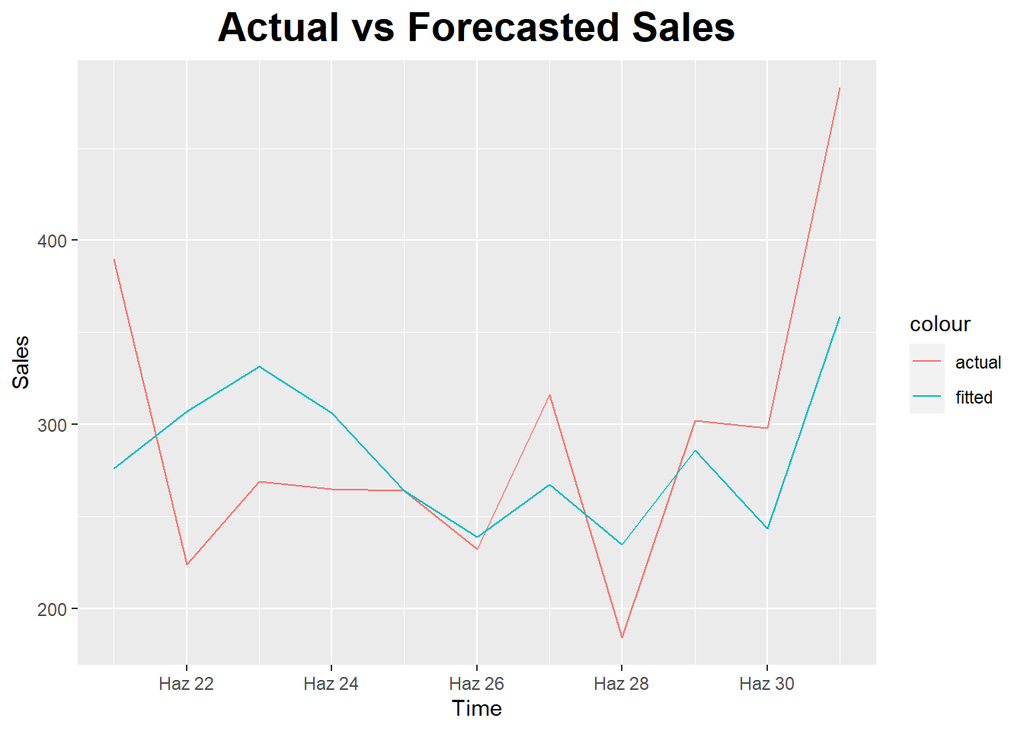

```r
ggplot(tayt_daily_te ,aes(x=event_date)) +
        geom_line(aes(y=sold_count,color='actual')) +
        geom_line(aes(y=forecastarimax,color='fitted')) + labs(title = "Actual vs Forecasted Sales",
       x = "Time",
       y = "Sales"
       )+
  theme(plot.title = element_text(color = "black", size = 20, face = "bold", hjust = 0.5),
        plot.subtitle = element_text(size = 10, face = "bold", hjust = 0.5),
        plot.caption = element_text(face = "italic", hjust = 0))
```

There is ultra difference in forecasted values between ARIMA and ARIMAX models. As can be seen from plot above, regressors improved model.

# Conclusion

In this study forecasting models are constructed for various products that are being sold in Trendyol. Products were decomposed to their seasonal and trend components, after deciding on the appropriate decomposition technique, random components of the products are evaluated in terms of their autocorrelation and partial autocorrelation plots to choose the best ARIMA model. Potential regressors are investigated and added to the model according to their WMAPE values. In overall, models resulted well and they can be used in forecasting the upcoming sales volumes. Some of assumptions made such as taking the last trend value and considering it as constant reduced the overall performance of the models, and also since we used the regressor values from test set instead of predicting them, error rates of the real-time forecasts would be higher than the values found in this study. If future product prices were given, more precise forecasting might be achieved. Furthermore, because the data had a large number of missing values, using such variables as regressors was useless. We haven’t used other sources like Google Trends to back up our forecasts since we all agreed that sometimes the best data to use is just the basic facts. Using other resources may result in better results.